# Introduction à l’intelligence artificielle

Une brève excursion dans le monde du machine learning

Kévin Polisano

kevin.polisano@cnrs.fr

CNRS, Laboratoire Jean Kuntzmann

December 26, 2024

## Plan de la présentation

1. Introduction
2. Les modèles linéaires
3. Généalogie des réseaux de neurones artificiels
4. Deep learning – les réseaux de neurones convolutifs
5. Conclusion

# Introduction

## Définitions

### Intelligence artificielle et apprentissage statistique

- Intelligence artificielle (IA) : ensemble de théories et de techniques visant à réaliser des machines capables de simuler l’intelligence humaine.
- Apprentissage statistique ou *Machine Learning* (ML) : champ d’étude de l’intelligence artificielle qui se fonde sur des approches mathématiques et statistiques pour donner aux ordinateurs la capacité d’« apprendre » à partir de données, c’est-à-dire d’améliorer leurs performances à résoudre des tâches sans être explicitement programmés pour chacune.

Source : [Wikipédia](https://fr.wikipedia.org/wiki/Intelligence_artificielle)

## Panorama de l’intelligence artificielle

### Le machine learning est une branche de l’IA

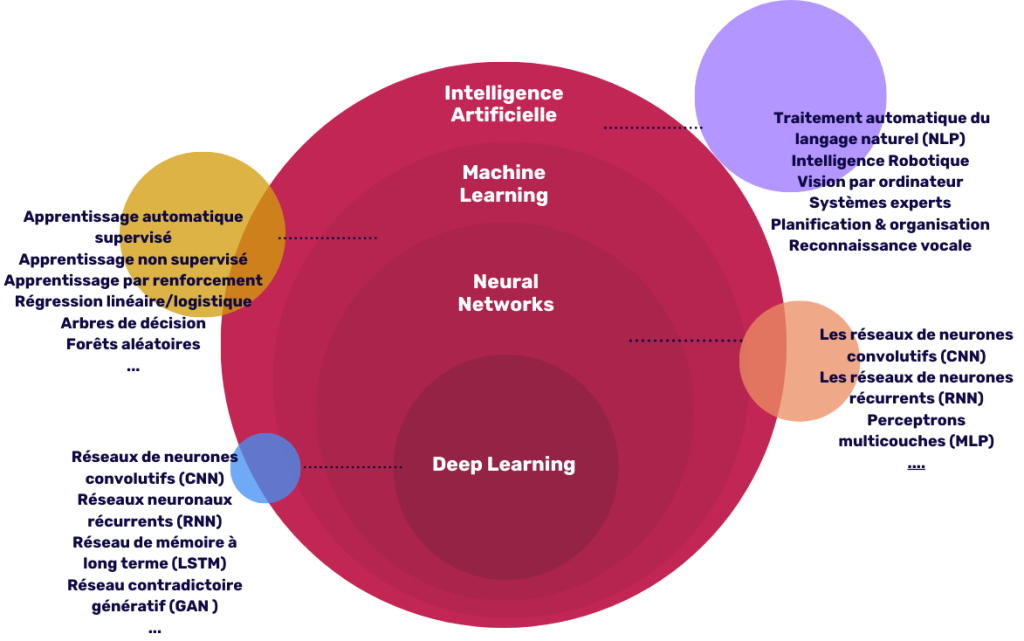

Source : [inventiv-it.fr](https://inventiv-it.fr/ai-machine-learning-deep-learning/)

## La carte du Machine Learning

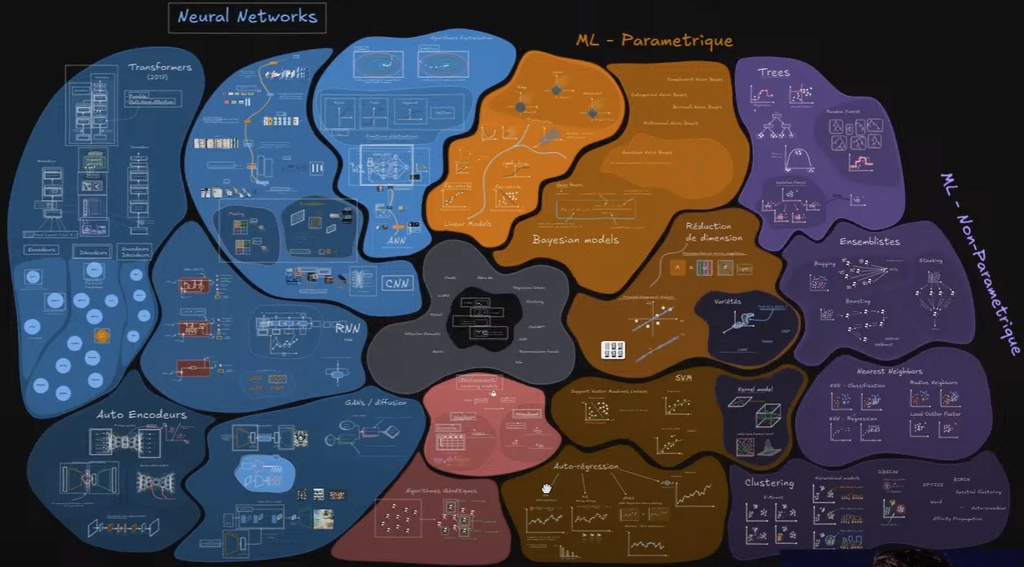

Source : [Machine Learnia](https://www.youtube.com/watch?v=mT6NnslbNLM)

# Les modèles linéaires

## La régression linéaire

### Prédiction du prix d’une maison en fonction de sa superficie

Des **données** d’entrainement $\color{red} (x_1,y_1),\dotsc,(x_n,y_n)$

- $x_i$ : superficie de la maison
- $y_i$ : prix de la maison
- $n$ : nombre de données

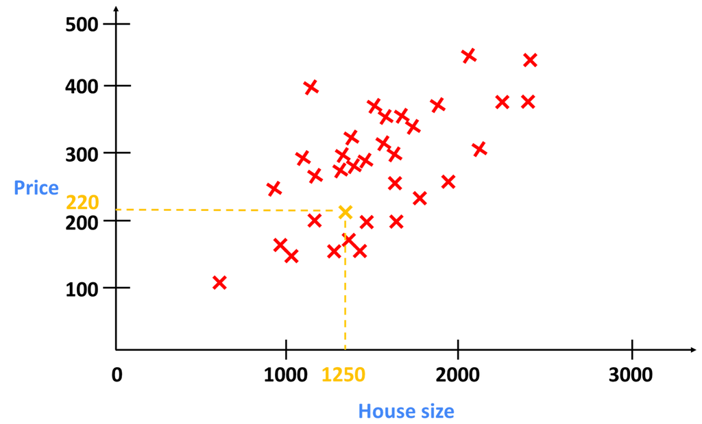

Source : [datahacker](https://datahacker.rs/002-machine-learning-linear-regression-model/)

## La régression linéaire

- Un **modèle** de prédiction linéaire $\color{blue} f_{w,b}$
- Une **fonction de coût** mesurant l’erreur *(quadratique moyenne)* :
  $${\color{red}J({\color{blue}w},{\color{blue}b})} = \frac{1}{n} \sum_{i=1}^n {\color{red}\ell({\color{orange}y_i}, {\color{blue}f_{w,b}
  ({\color{orange}x_i})})}, \quad {\color{red}\ell(y,\hat y)=(y-\hat y)^2}$$

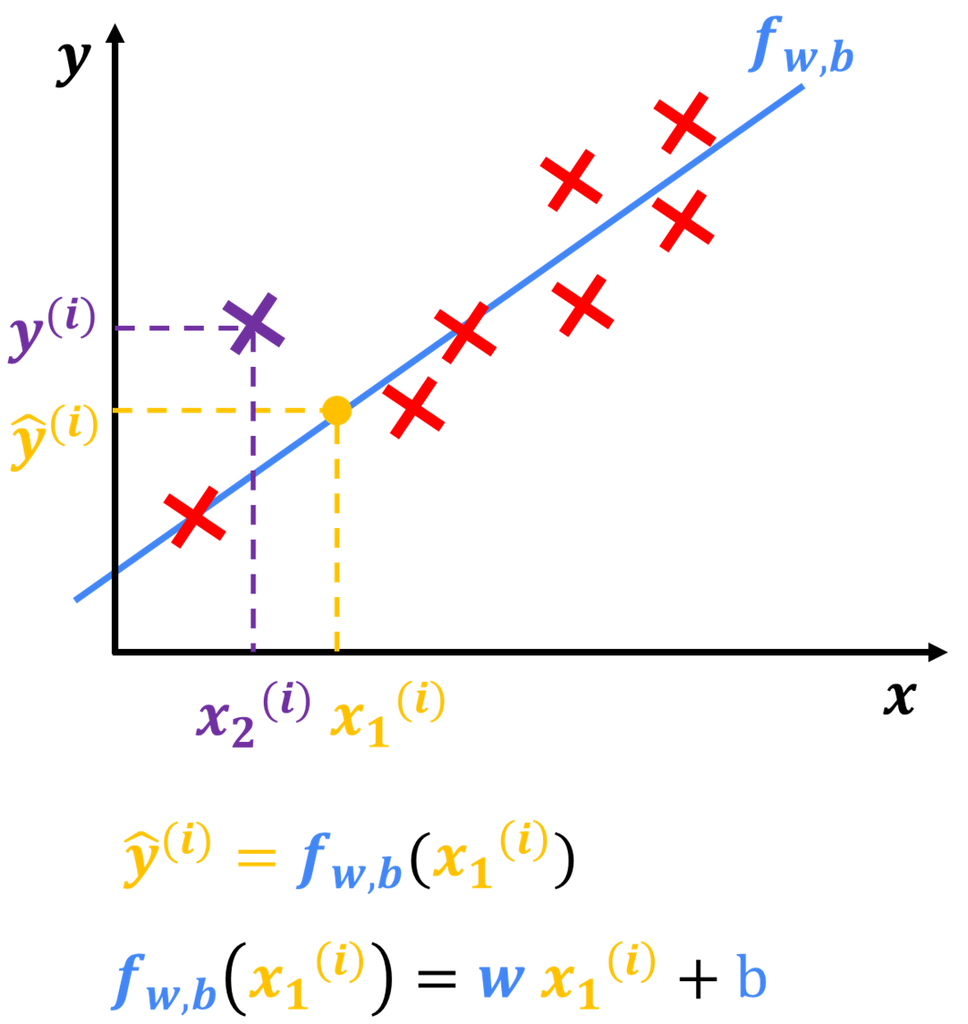

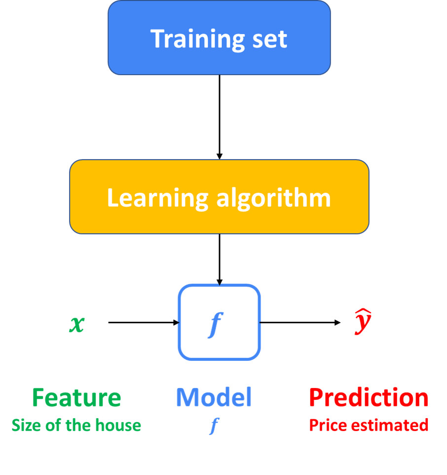

Source : [datahacker](https://datahacker.rs/002-machine-learning-linear-regression-model/)

## La régression linéaire

- **Minimisation** du coût : $\displaystyle \color{red} (w^{\star},b^{\star})=\underset{w,b}{\mathrm{argmin}}\; J(w,b)$

[interactive chart not shown]

Source : [Geogebra](https://www.geogebra.org/m/xC6zq7Zv)

## Visualisation de la descente de gradient

[video not shown]

Source : [Son The Nguyen](https://www.youtube.com/watch?v=GP6fl2nxs9k)

## La régression linéaire

### Une simple couche de neurone

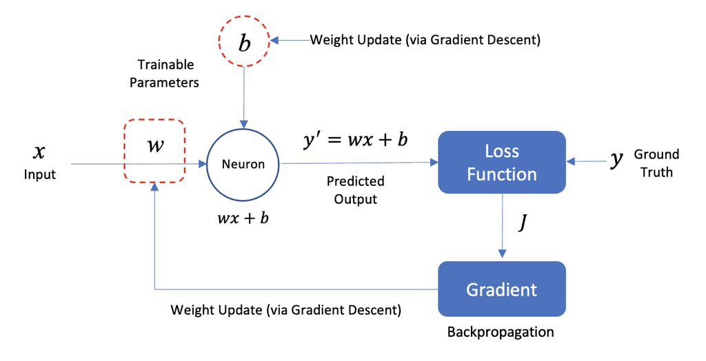

Source : [Learn OpenCV](https://learnopencv.com/tensorflow-keras-tutorial-linear-regression/)

## Les 4 principaux ingrédients du ML

1. Des données
2. Un modèle
3. Une fonction de coût
4. Un algorithme d’optimisation

[video not shown]

Source : [Machine Learnia](https://www.youtube.com/watch?v=XUFLq6dKQok)

## La régression polynomiale

### Un autre modèle linéaire plus complexe

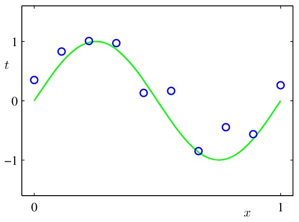

- Fitting des données bruitées ${\color{blue}y_i}={\color{green}\sin(2\pi x_i)}+\epsilon_i$ avec un polynôme de degré $M$ :
  $$\color{red} f_{\boldsymbol{w}}(x) = w_0 + w_1 x + w_2 x^2 + \dotsc + w_M x^M = \boldsymbol{\psi}(x)^{\intercal} \boldsymbol{w}$$
- $\boldsymbol{\psi}(x)=[1,x,x^2,\dotsc,x^M]^{\intercal}$ est un *feature mapping*. On peut utiliser les moindres carrés puisque $f_{\boldsymbol{w}}(x)=\boldsymbol{\psi}(x)^{\intercal} \boldsymbol{w}$ est linéaire en $\boldsymbol{w}$.

Source : (Bishop 2006)

## La régression polynomiale

### Underfitting (M=0,1) vs. bon modèle (M=3) vs. overfitting (M=9)

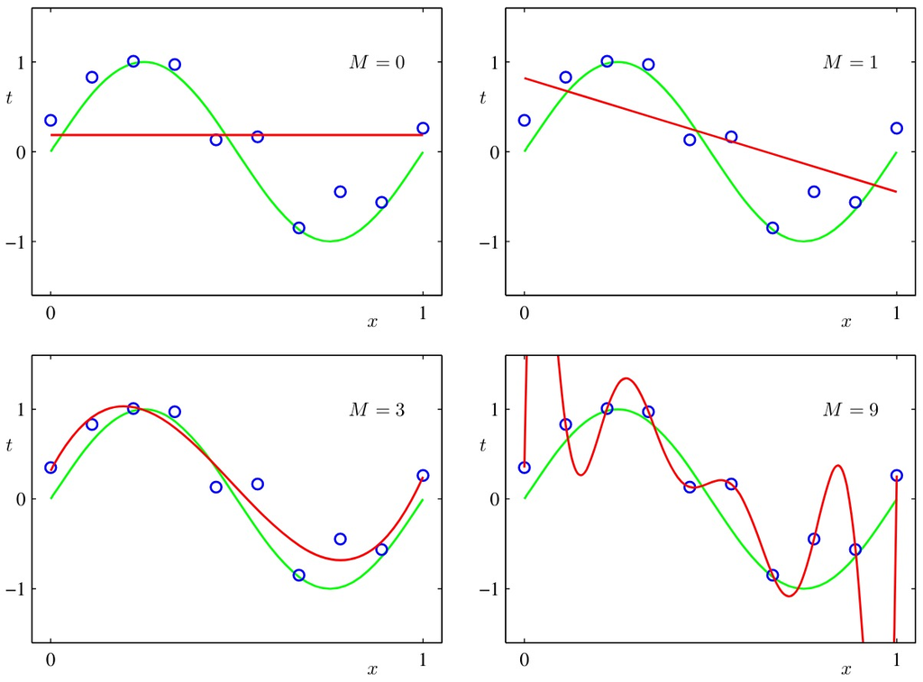

Source : (Bishop 2006)

## La régression polynomiale

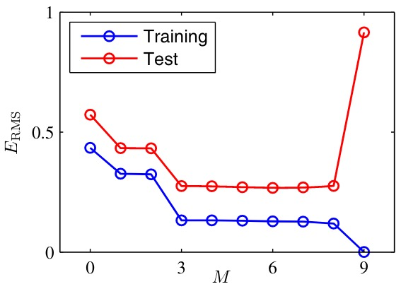

[figure not shown]

- Plus $M$ augmente, plus les coefficients $w_i^{\star}$ explosent.
- Le polynôme $\color{red} f_{\boldsymbol{w}}(x)$ finit par interpoler les données $\color{blue} (x_i,y_i)$ (erreur de training nulle pour $M=9$), avec de fortes oscillations entre ces points.
- Le modèle peine alors à généraliser sur les données de test (l’erreur grimpe pour $M=9$). Il faut ajuster l’hyperparamètre $M$ sur données de validation (étape de sélection de modèle).

Source : (Bishop 2006)

## Partitionnement du dataset

### Training vs. validation vs. testing

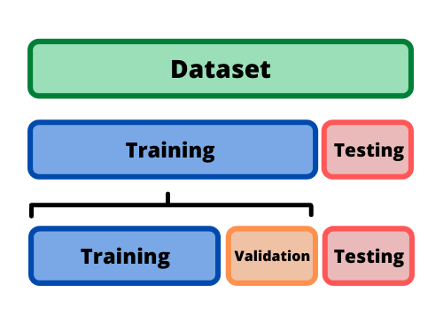

Source : [dhavalpatel](https://dhavalpatel2101992.wordpress.com/2021/05/21/kaggle-titanic-dataset-cleaning-split-data-into-train-validation-and-test-set/)

## Types d’apprentissages

### Supervisés, non-supervisés et par ré-enforcement

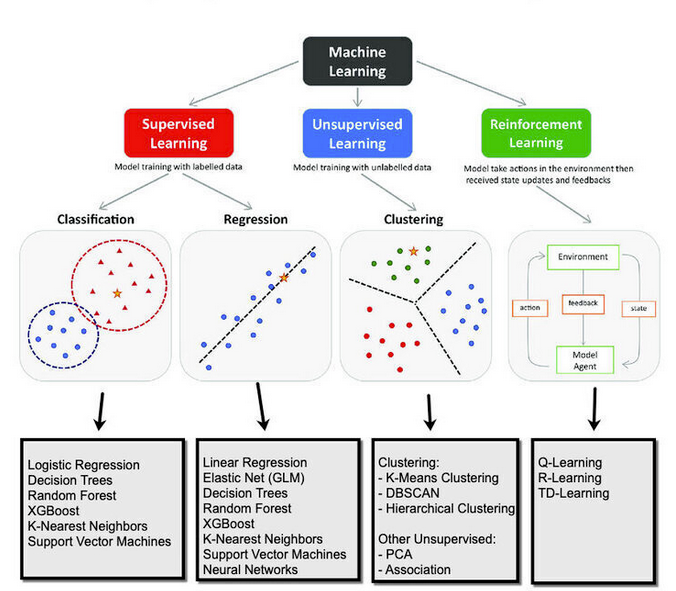

Source : [Techplayon](https://www.techplayon.com/machine-learning-supervised-unsupervised-reinforcement/)

# Généalogie des réseaux de neurones artificiels

## L’invention des neurones artificiels

### (McCulloch and Pitts 1943)

[video not shown]

Source : [Machine Learnia](https://www.youtube.com/watch?v=XUFLq6dKQok)

## L’invention du Perceptron

### (Rosenblatt 1958)

[video not shown]

Source : [Machine Learnia](https://www.youtube.com/watch?v=XUFLq6dKQok)

## Classification à l’aide d’un Perceptron

### La classification binaire

[video not shown]

Source : [Machine Learnia](https://www.youtube.com/watch?v=VlMm4VZ6lk4)

## Classification à l’aide d’un Perceptron

### La fonction d’activation (sigmoïde) et la fonction de coût (vraisemblance)

[video not shown]

Source : [Machine Learnia](https://www.youtube.com/watch?v=VlMm4VZ6lk4)

## Le Perceptron Multicouche

### … et la rétropropagation du gradient (Rumelhart et al. 1986)

[video not shown]

Source : [Machine Learnia](https://www.youtube.com/watch?v=XUFLq6dKQok)

## L’efficacité du Perceptron Multicouche

### 3 perceptrons pour créer une forme triangulaire

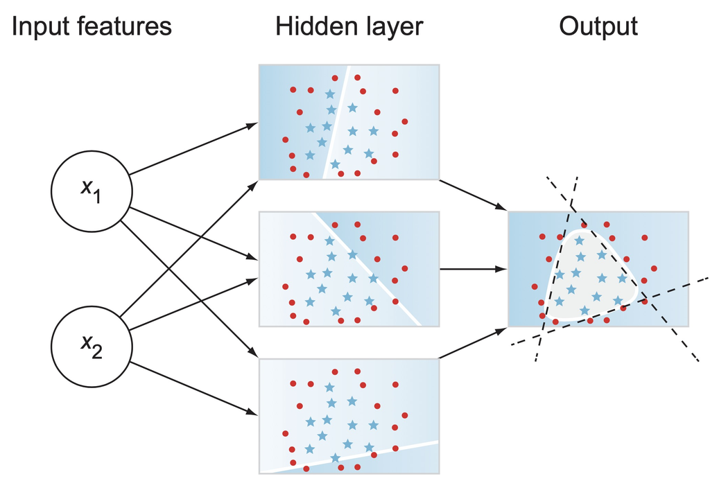

Source : (Elgendy 2020)

## L’efficacité du Perceptron Multicouche

### Linéariser les frontières de décision complexes

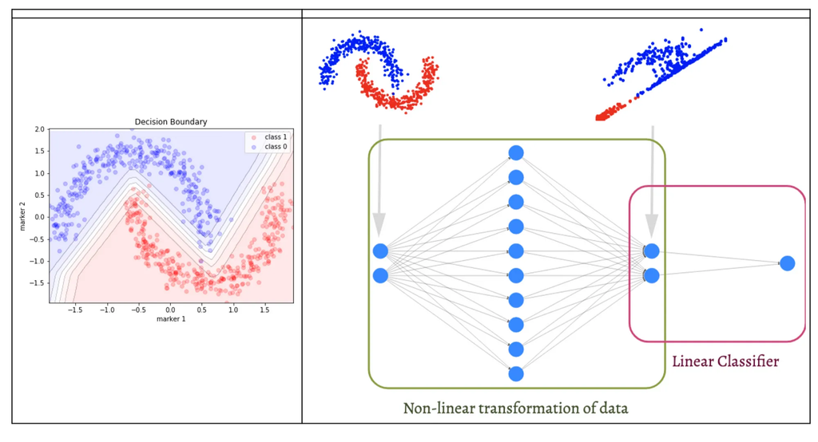

Source : [Towards Data Science](https://towardsdatascience.com/guide-to-interpretable-machine-learning-d40e8a64b6cf)

## Représentation d’un Perceptron Multicouche

### Un simple réseau de neurones à 3 couches

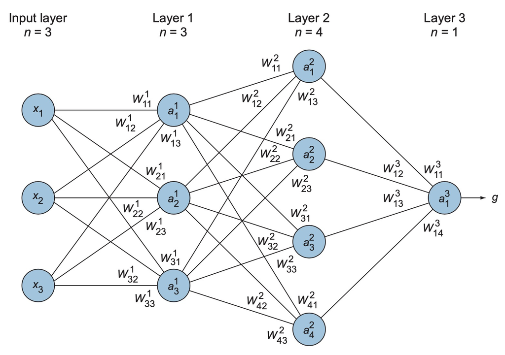

Source : (Elgendy 2020)

## Formalisation d’un Perceptron Multicouche

### Cascades de multiplication matricielles et d’activation

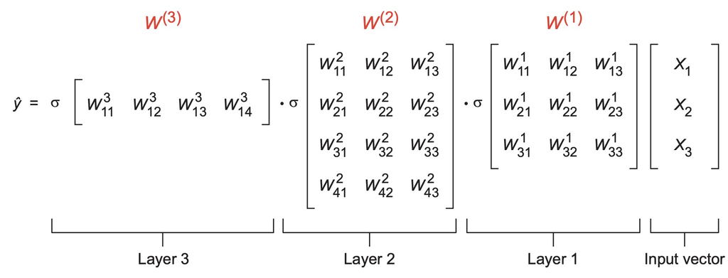

Source : (Elgendy 2020)

## Formalisation d’un Perceptron Multicouche

### Cascades de multiplication matricielles et d’activation

[video not shown]

Source : [3blue1brown](https://www.youtube.com/watch?v=aircAruvnKk)

## Que se passe-t-il dans un réseau de neurones ?

### Visualisation de la linéarisation de la frontière de décision

[video not shown]

Source : [Alexandre TL](https://www.youtube.com/watch?v=yFcdKE6YI0E&t=330s)

## L’efficacité du Perceptron Multicouche

### Apprendre des frontières de décision complexes

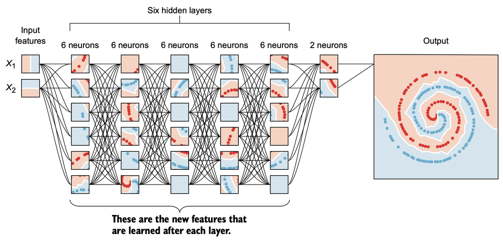

Source : [Playground Tensorflow](https://playground.tensorflow.org)

## Pourquoi les réseaux de neurones fonctionnent ?

### Parce qu’ils approchent des fonctions complexes

[video not shown]

Source : [DataMListic](https://www.youtube.com/watch?v=O45AaRPQhuI)

## Pourquoi les réseaux de neurones fonctionnent ?

### Parce qu’ils approchent des fonctions complexes

[video not shown]

Source : [Emergent Garden](https://www.youtube.com/watch?v=0QczhVg5HaI)

## Théorème d’approximation universelle

### Fonctions continues approchables par un réseau de neurones à 2 couches

**Théorème (Cybenko, 1989, Hornik, 1991)**

Soit $\sigma:\mathbb{R}\rightarrow \mathbb{R}$ une fonction non constante, bornée et continue. Soit $I_m$ le cube unité $m$-dimensionnel $[0, 1]^m$. L’espace des fonctions continues à valeurs réelles sur $I_m$ est noté $C(I_m)$. Alors, pour tout $\epsilon > 0$ et toute fonction $f \in C(I_m)$, il existe un entier $N$, des constantes réelles $v_i, b_i \in \mathbb{R}$ et des vecteurs réels $\boldsymbol{w}_i \in \mathbb{R}^m$ pour $i = 1, \dotsc, N$, tels que nous puissions définir :

$$F(\boldsymbol{x}) = \sum_{i=1}^N v_i \sigma\left(\boldsymbol{w}_i^T \boldsymbol{x}+b_i\right)=\boldsymbol{v}^T \sigma\left(\mathbf{W}^T \boldsymbol{x}+\boldsymbol{b}\right)$$
comme une approximation de la fonction $f$, c’est-à-dire,
$$|f(\boldsymbol{x})-F(\boldsymbol{x})|<\epsilon, \quad \forall \boldsymbol{x}\in I_m$$

## Résumé de l’apprentissage supervisé

### Point de vue général

1. Des données d’entrainement $(\boldsymbol{x}_1,y_1),\dotsc,(\boldsymbol{x}_n,y_n)$
2. Un modèle, une famille de fonctions $f\in \mathcal{H}$ assurant $y_i\approx f(\boldsymbol{x}_i)$
3. Une fonction de coût $\ell$ mesurant la qualité de l’approximation
4. Un algorithme d’optimisation trouvant $f\in \mathcal{H}$ qui minimise le coût
   $$\min_{f\in \mathcal{H}} \frac{1}{n} \sum_{i=1}^n \ell(y_i, f(\boldsymbol{x}_i))$$

## Résumé de l’apprentissage supervisé

### Point de vue des réseaux de neurones

1. Des données d’entrainement $(\boldsymbol{x}_1,y_1),\dotsc,(\boldsymbol{x}_n,y_n)$
2. Un réseau à $k$ neurones soit un groupe de poids $(\boldsymbol{w}_1,\dotsc \boldsymbol{w}_k, b_1, \dotsc, b_k)$ assurant
   $$y_i\approx \{NN(\boldsymbol{w}_1,\dotsc \boldsymbol{w}_k, b_1, \dotsc, b_k)\}(\boldsymbol{x}_i)$$
3. Une fonction de coût $\ell$ mesurant la qualité de l’approximation
4. Un algorithme d’optimisation trouvant les poids $(\boldsymbol{w}_1,\dotsc \boldsymbol{w}_k, b_1, \dotsc, b_k)$ qui minimisent le coût
   $$\min_{(\boldsymbol{w}_k, b_k)} \frac{1}{n} \sum_{i=1}^n \ell(y_i, \{NN(\boldsymbol{w}_1,\dotsc \boldsymbol{w}_k, b_1, \dotsc, b_k)\}(\boldsymbol{x}_i))$$

# Deep learning – les réseaux de neurones convolutifs

## Classification d’images

### Reconnaissance de chiffres (MNIST)

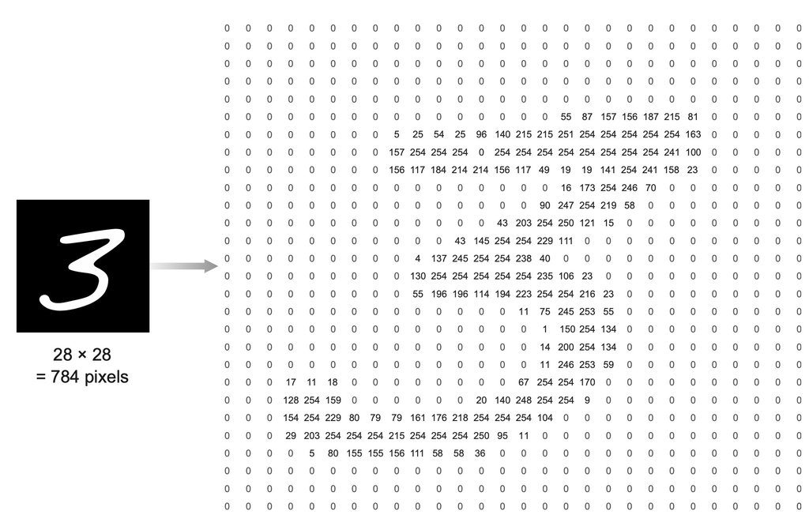

Source : (Elgendy 2020)

## Image en couleurs

### 3 canaux RGB

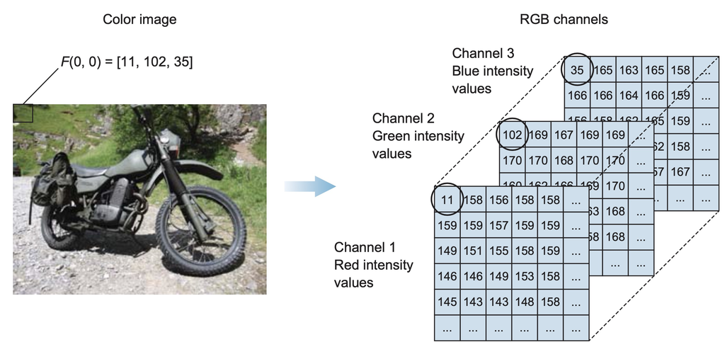

Source : (Elgendy 2020)

## Classification d’images

### Extraction de caractéristiques

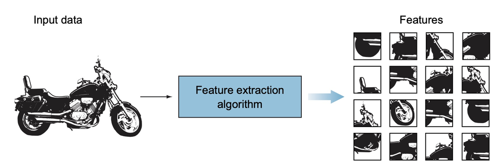

Source : (Elgendy 2020)

## Classification d’images

### Méthode traditionnelle (*handcrafted features*) vs moderne (*deep learning*)

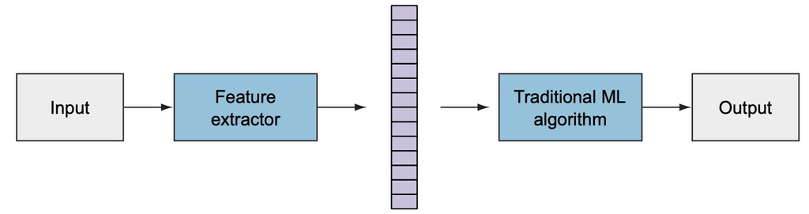

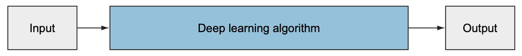

Source : (Elgendy 2020)

## Classification d’images

### Discriminer deux chiffres

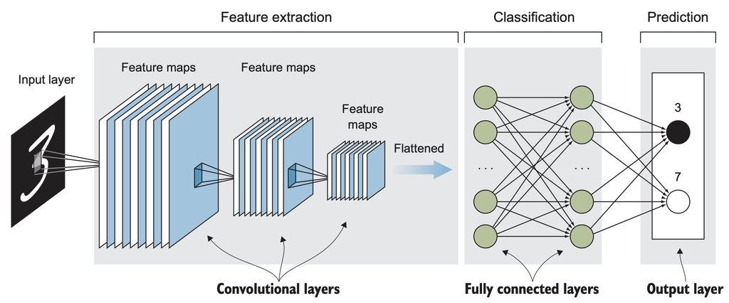

Source : (Elgendy 2020)

## Briques de base d’un CNN

### Les filtres de convolution

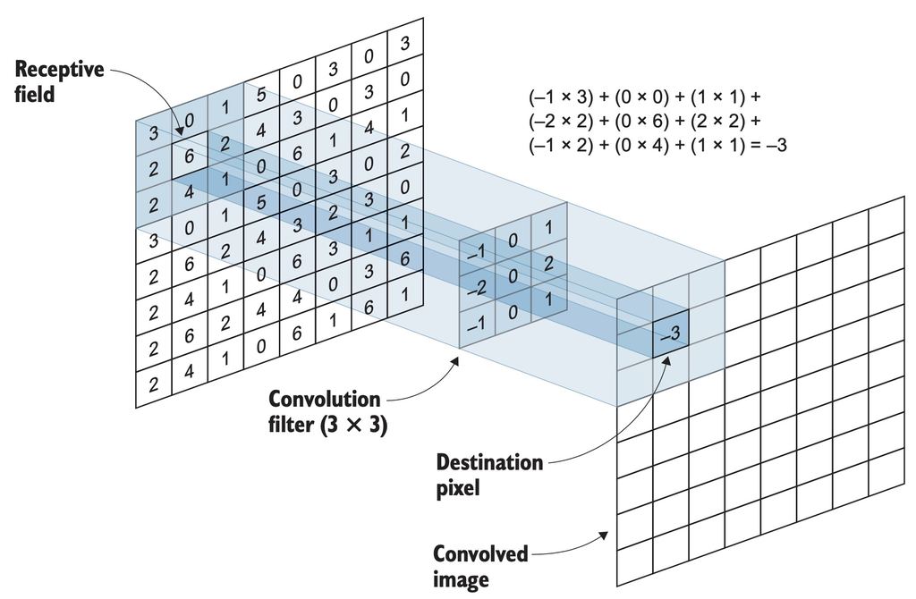

Source : (Elgendy 2020)

## Briques de base d’un CNN

### Les filtres de convolution

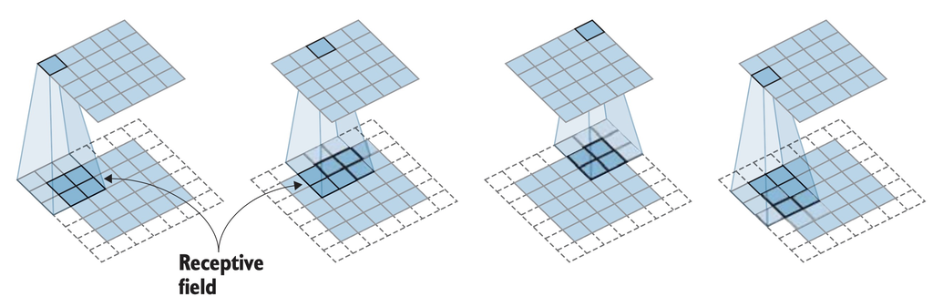

Source : (Elgendy 2020)

## Briques de base d’un CNN

### Les filtres de convolution

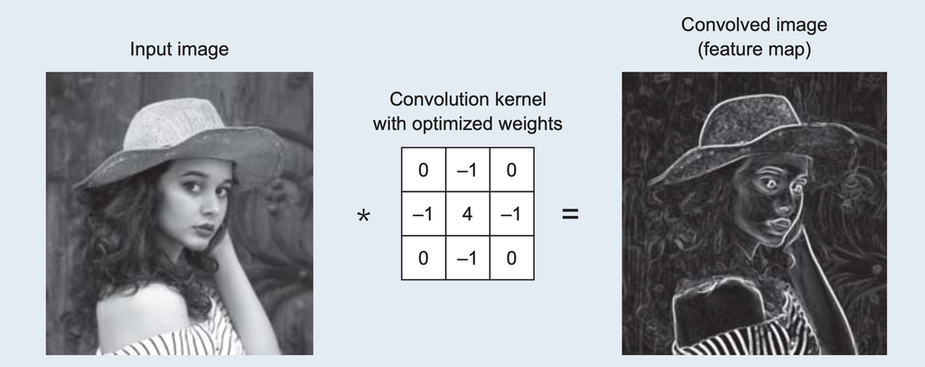

Source : (Elgendy 2020)

## Briques de base d’un CNN

### Les filtres de convolution

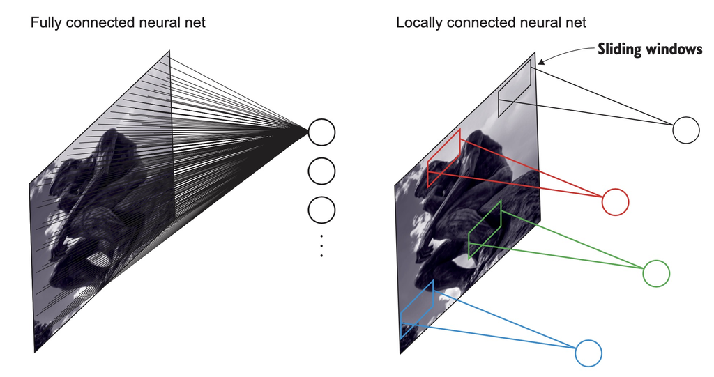

Source : (Elgendy 2020)

## Briques de base d’un CNN

### Les filtres de convolution

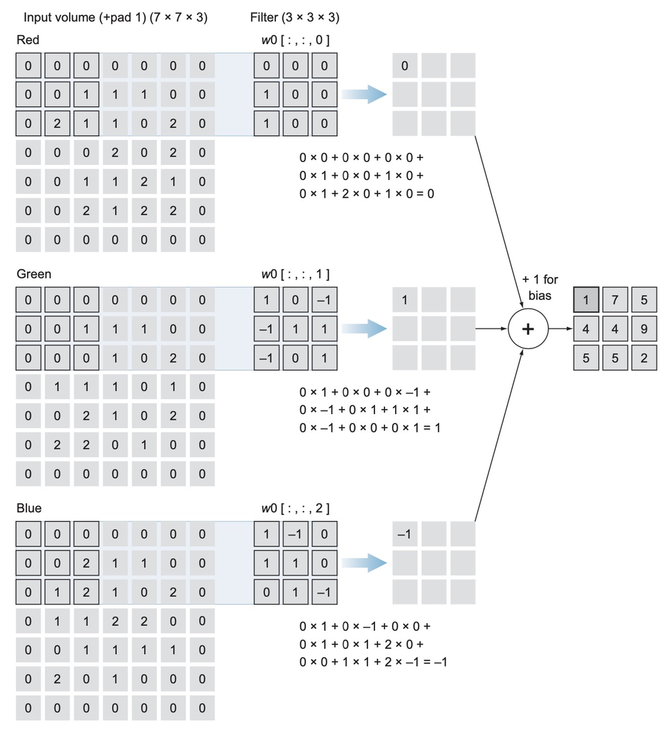

Source : (Elgendy 2020)

## Briques de base d’un CNN

### Le max pooling

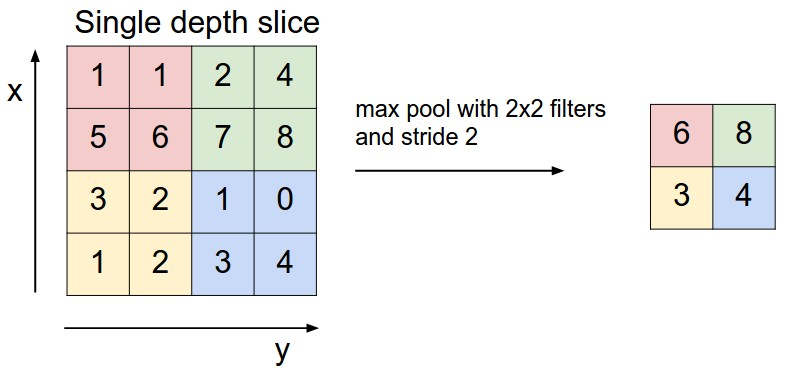

Source : [CS231n](https://cs231n.github.io/convolutional-networks/)

## Briques de base d’un CNN

### Le max pooling

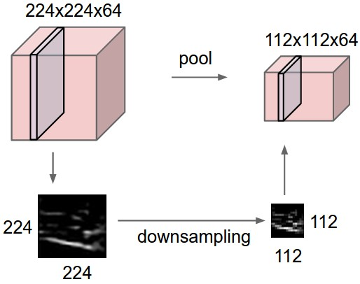

Source : [CS231n](https://cs231n.github.io/convolutional-networks/)